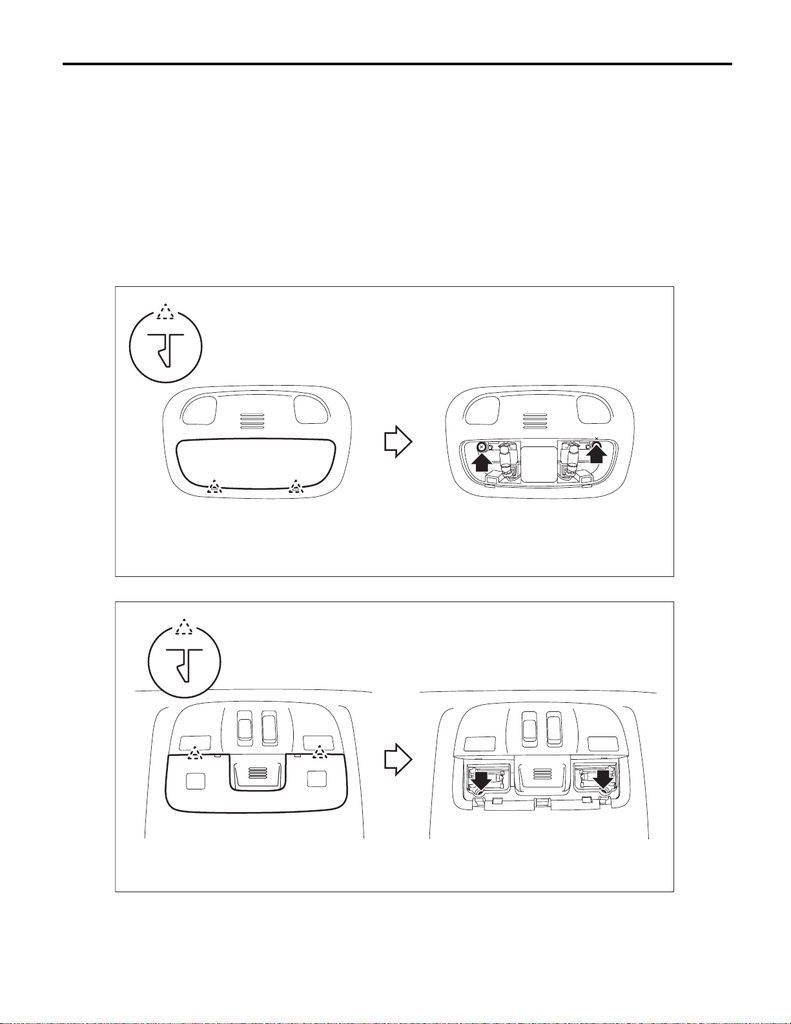

LI-60

Spot Map Light

LIGHTING SYSTEM

32.Spot Map Light

A: REMOVAL

1) Disconnect the ground cable from battery. <Ref. to NT-5, BATTERY, NOTE, Note.>

NOTE:

For models other than STI model, disconnect the ground terminal from battery sensor.

2) Remove the light assembly - map.

CAUTION:

When using a flat tip screwdriver, apply protective tape or cloth and be careful not to cause damage.

(1) Release the claws and remove the lens.

(2) Remove the screws.

• Model without sunroof

• Model with sunroof

(3) Disconnect the connector and remove the light assembly - map and the map light bulb.

CAUTION:

Use a dry clean cloth so that no grease or water adheres to the glass portion of the bulb.

LI-01227

LI-01331

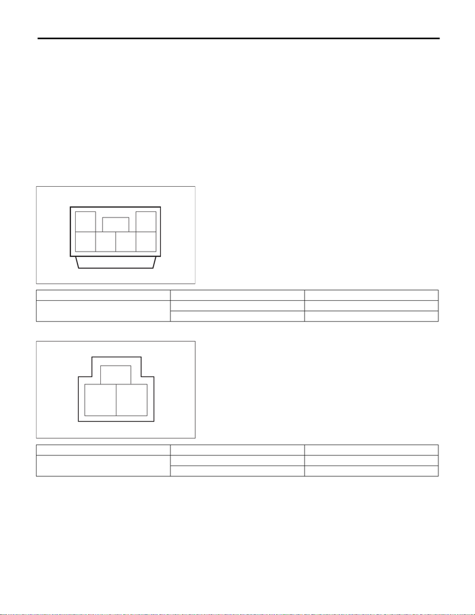

LI-61

Spot Map Light

LIGHTING SYSTEM

B: INSTALLATION

1) Install the map light bulb and light assembly - map.

CAUTION:

Use a dry clean cloth so that no grease or water adheres to the glass portion of the bulb.

2) Connect the battery ground terminal. <Ref. to NT-5, BATTERY, NOTE, Note.>

NOTE:

For models other than STI model, connect the ground terminal to battery sensor.

C: INSPECTION

1) Measure the resistance between connector terminals.

Preparation tool:

Circuit tester

• Model without sunroof

• Model with sunroof

2) Replace the light assembly - map if the inspection result is not within the standard value.

LI-01808

4

3

6 5

12

Terminal No. Inspection conditions Standard

1 — 2

Switch OFF 1 MΩ or more

Switch ON Approx. 18 Ω

LI-01747

2 1

Terminal No. Inspection conditions Standard

1 — 2

Switch OFF 1 MΩ or more

Switch ON Approx. 18 Ω